# Final_Project

Author

Rachel Bittner

## GitHub Repo:

https://github.com/bittnation/ENVS_193DS_Final

```r
list.files()
```

```
[1] "193 DS Final.Rproj"      "Code"
[3] "Data"                    "docs"
[5] "Final_Project.qmd"       "Final_Project.rmarkdown"
[7] "README.md"
```

```r
library(tidyverse)
library(janitor)
library(ggplot2)
library(dplyr)
# reading in basic packages


# read in data sets
sst <- read.csv("Data/SST_SB.csv")
```

# Problem 1. Research Writing

1. In part 1, they used Pearson’s correlation. The key word “correlation” suggest that they either performed a Pearson’s correlation test or Spearman’s rho. Since kg year-1 and km are both continuous variables instead of rankings it is likely Pearson’s r. In part 2, they used a one-way ANOVA. The key phrase “difference in average” indicates ANOVA which aims to compare the means (averages) of more than one group. The type of ANOVA was determined by the number of groups, the results indicated the comparison of more than three groups which requires a one-way ANOVA.
2. To add more context to the results, my coworker should provide a Tukey’s Honestly significant Difference and key ANOVA statistics. It is important to include Tukey’s HSD because it provides context as to which of the 6 groups were actually different from each other. This is test is important because it prevents Type I errors. Include key ANOVA statistics such as test type, F-value, degrees of freedom, and significance level to strengthen the statistical results. It aids readers ability to interpret data and draw conclusions and it promotes transparency and reduces skeptical (fix tense), the p-value doesn’t tell the whole story so it is important to communicate all statistical results.
3. ANOVA statistics: We found that there was a significant difference in average nitrogen load (kg year-1) between sources (urban land, atmospheric deposition, fertilizer, waste water treatment, and grasslands) (one-way ANOVa, F(df among groups, df withing groups),p = 0.02, a = significance level). Tukey’s HSD: On Average, urban land tended to have [higher or lower] nitrogen loads (kg year-1) than grasslands ( _ kg year-1 (higher or lower), _ % CI: [x:y] kg year-1) and fertilizer (_ kg year-1 (higher or lower), _ % CI: [x:y] kg year-1 )…

# Problem 2. Data Visualization

```r
sst_clean <- sst |>
  clean_names() |> #cleans column names
  mutate(
    date = ymd(date),
    year = year(date),
    month = month(date, label = TRUE, abbr = TRUE)
          ) |> #making a separate column with just the year and another with just the month (month is converted from numeric to abbreviated version)

 #filter to only include data from years of interst

 filter(year %in% c("2018", "2019", "2020", "2021", "2022", "2023")) |>


 # remove date (ymd) format, site, latitude, longitude,

select(!c(date, site, latitude, longitude))

sst_clean |> #displaying 5 random rows of cleaned data
  slice_sample(n = 5)
```

```
   temp year month
1 16.50 2023   Dec
2 14.33 2020   May
3 16.26 2023   Dec
4 14.37 2018   Mar
5 14.66 2022   Dec
```

```r
str(sst_clean) #displaying table
```

```
'data.frame':   41553 obs. of  3 variables:
 $ temp : num  14.4 14.6 14.9 15.2 15.6 ...
 $ year : num  2018 2018 2018 2018 2018 ...
 $ month: Ord.factor w/ 12 levels "Jan"<"Feb"<"Mar"<..: 1 1 1 1 1 1 1 1 1 1 ...
```

```r
#create summary data set using clean data

sst_summary <- sst_clean |>
#group so that we can find the months mean in its individual year
  group_by(year, month) |>
# re order data
    mutate(month = as_factor(month),
         month = fct_relevel(
           month,
           "Jan", "Feb", "Mar", "Apr", "May", "Jun", "Jul", "Aug", "Sep", "Oct", "Nov", "Dec")
         ) |> #months in correct calender order
  mutate(year = as_factor(year)) |> #making data categorical instead of numerical

#summarize mean sst
  summarize(
    mean_monthly_sst = mean(temp),
    .groups = "drop" #removing extra info for structure
    )
sst_summary #display summary
```

```
# A tibble: 72 × 3
   year  month mean_monthly_sst
   <fct> <ord>            <dbl>
 1 2018  Jan               15.0
 2 2018  Feb               14.3
 3 2018  Mar               13.5
 4 2018  Apr               12.8
 5 2018  May               13.6
 6 2018  Jun               15.5
 7 2018  Jul               18.2
 8 2018  Aug               19.6
 9 2018  Sep               18.2
10 2018  Oct               18.5
# ℹ 62 more rows
```

```r
str(sst_summary)
```

```
tibble [72 × 3] (S3: tbl_df/tbl/data.frame)
 $ year            : Factor w/ 6 levels "2018","2019",..: 1 1 1 1 1 1 1 1 1 1 ...
 $ month           : Ord.factor w/ 12 levels "Jan"<"Feb"<"Mar"<..: 1 2 3 4 5 6 7 8 9 10 ...
 $ mean_monthly_sst: num [1:72] 15 14.3 13.5 12.8 13.6 ...
```

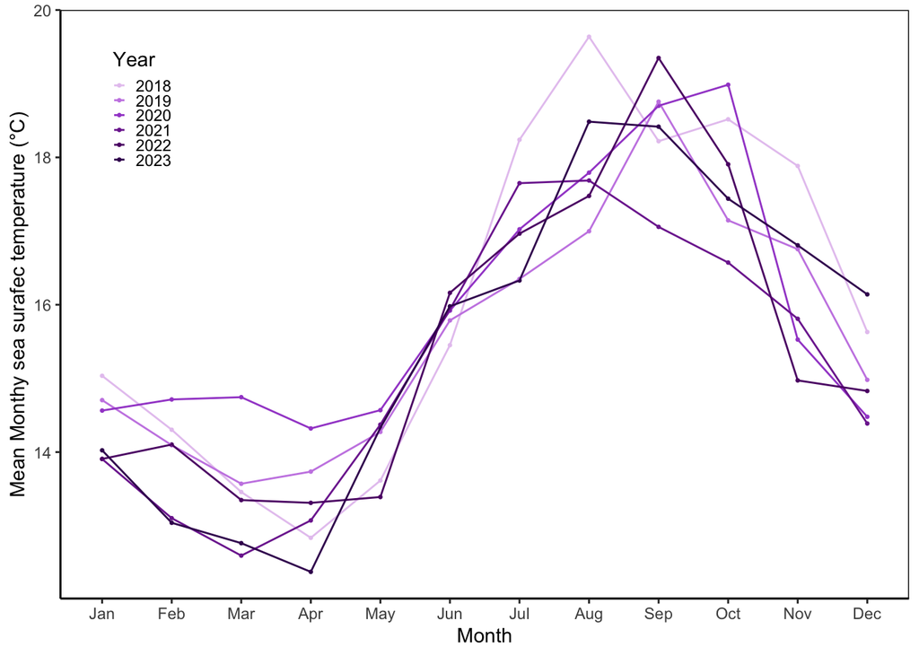

```r
# creating plot using cleaned sst data set
sst_plot <- ggplot(data = sst_summary,
   aes(x = month, #setting month as x-axis
       y = mean_monthly_sst, #setting mean sst on y-axis
       color = year, #coloring by year
       group = year #connecting lines between groups
   )) +
  geom_point(size =0.5) +
  geom_line()+
  labs(
    x = "Month",
    y = "Mean Monthy sea surafec temperature (°C)",
    color = "Year"
  ) +
  theme_classic() +
  theme(legend.position = c(0.05, 0.95),         # position inside plot (x, y)
  legend.justification = c(0, 1),          # anchor legend’s top-left corner
  # optional for visibility
  legend.key.size = unit(0.25, "cm"),
  panel.border = element_rect(color = "black", fill = NA, linewidth = 0.5)) +
scale_color_manual(
values = c(
"2018" = "#E6C8F0",
"2019" = "#C989E5",
"2020" = "#A44FCF",
"2021" = "#7E2C9E",
"2022" = "#5E1675",
"2023" = "#3E065F"
))
sst_plot
```

# Problem 3. Data Analysis

# Problem 4. Affective and Exploratopry Visualizations